# Project Credit Card

venkat

2022-10-27

```r
knitr::opts_chunk$set(echo = TRUE)
```

```r
#remove.packages("rlang")
#install.packages("rlang")
#update.packages("rlang")
```

```r
#install.packages("rlang")
#install.packages("read_excel")
#install.packages("gmodels")
#install.packages("fastDummies")
#install.packages("skimr")
#install.packages("pivottabler")
#install.packages("lessR")
library(lessR)
library(pivottabler)
library(fastDummies)
library(gmodels)
library(skimr)
library(forecast)
library(tidyverse)
```

```r
library(readr)
library(ggplot2)
library(gridExtra)
library(dplyr)
#install.packages("corrplot")
library(corrplot)
#install.packages("MASS")
library(MASS)
library(ggplot2)
library(reshape)
#install.packages("GoodmanKruskal")
library(GoodmanKruskal)
```

```r
df <- read_csv("Credit card customers.csv")
summary(df)
```

```
##    CLIENTNUM         Attrition_Flag      Customer_Age      Gender
##  Min.   :708082083   Length:10127       Min.   :26.00   Length:10127
##  1st Qu.:713036770   Class :character   1st Qu.:41.00   Class :character
##  Median :717926358   Mode  :character   Median :46.00   Mode  :character
##  Mean   :739177606                      Mean   :46.33
##  3rd Qu.:773143533                      3rd Qu.:52.00
##  Max.   :828343083                      Max.   :73.00
##  Dependent_count Education_Level    Marital_Status     Income_Category
##  Min.   :0.000   Length:10127       Length:10127       Length:10127
##  1st Qu.:1.000   Class :character   Class :character   Class :character
##  Median :2.000   Mode  :character   Mode  :character   Mode  :character
##  Mean   :2.346
##  3rd Qu.:3.000
##  Max.   :5.000
##  Card_Category      Months_on_book  Total_Relationship_Count
##  Length:10127       Min.   :13.00   Min.   :1.000
##  Class :character   1st Qu.:31.00   1st Qu.:3.000
##  Mode  :character   Median :36.00   Median :4.000
##                     Mean   :35.93   Mean   :3.813
##                     3rd Qu.:40.00   3rd Qu.:5.000
##                     Max.   :56.00   Max.   :6.000
##  Months_Inactive_12_mon Contacts_Count_12_mon  Credit_Limit
##  Min.   :0.000          Min.   :0.000         Min.   : 1438
##  1st Qu.:2.000          1st Qu.:2.000         1st Qu.: 2555
##  Median :2.000          Median :2.000         Median : 4549
##  Mean   :2.341          Mean   :2.455         Mean   : 8632
##  3rd Qu.:3.000          3rd Qu.:3.000         3rd Qu.:11068
##  Max.   :6.000          Max.   :6.000         Max.   :34516
##  Total_Revolving_Bal Avg_Open_To_Buy Total_Amt_Chng_Q4_Q1 Total_Trans_Amt
##  Min.   :   0        Min.   :    3   Min.   :0.0000       Min.   :  510
##  1st Qu.: 359        1st Qu.: 1324   1st Qu.:0.6310       1st Qu.: 2156
##  Median :1276        Median : 3474   Median :0.7360       Median : 3899
##  Mean   :1163        Mean   : 7469   Mean   :0.7599       Mean   : 4404
##  3rd Qu.:1784        3rd Qu.: 9859   3rd Qu.:0.8590       3rd Qu.: 4741
##  Max.   :2517        Max.   :34516   Max.   :3.3970       Max.   :18484
##  Total_Trans_Ct   Total_Ct_Chng_Q4_Q1 Avg_Utilization_Ratio
##  Min.   : 10.00   Min.   :0.0000      Min.   :0.0000
##  1st Qu.: 45.00   1st Qu.:0.5820      1st Qu.:0.0230
##  Median : 67.00   Median :0.7020      Median :0.1760
##  Mean   : 64.86   Mean   :0.7122      Mean   :0.2749
##  3rd Qu.: 81.00   3rd Qu.:0.8180      3rd Qu.:0.5030
##  Max.   :139.00   Max.   :3.7140      Max.   :0.9990
```

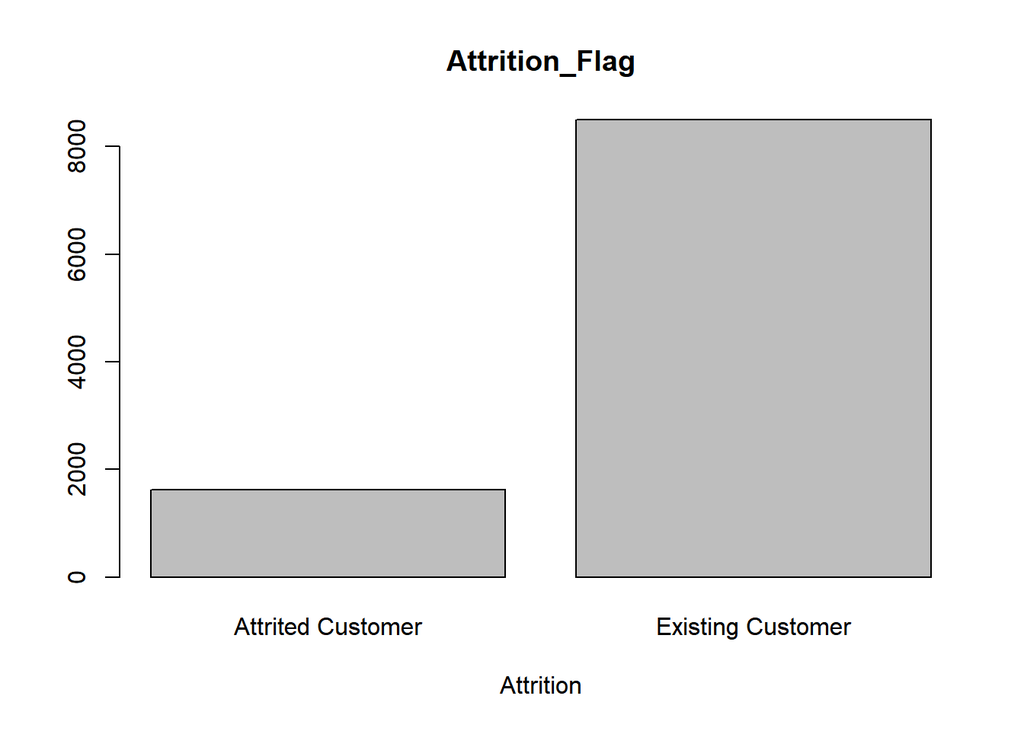

```r
b1 <- barplot(table(df$Attrition_Flag), main="Attrition_Flag",
   xlab="Attrition")
```

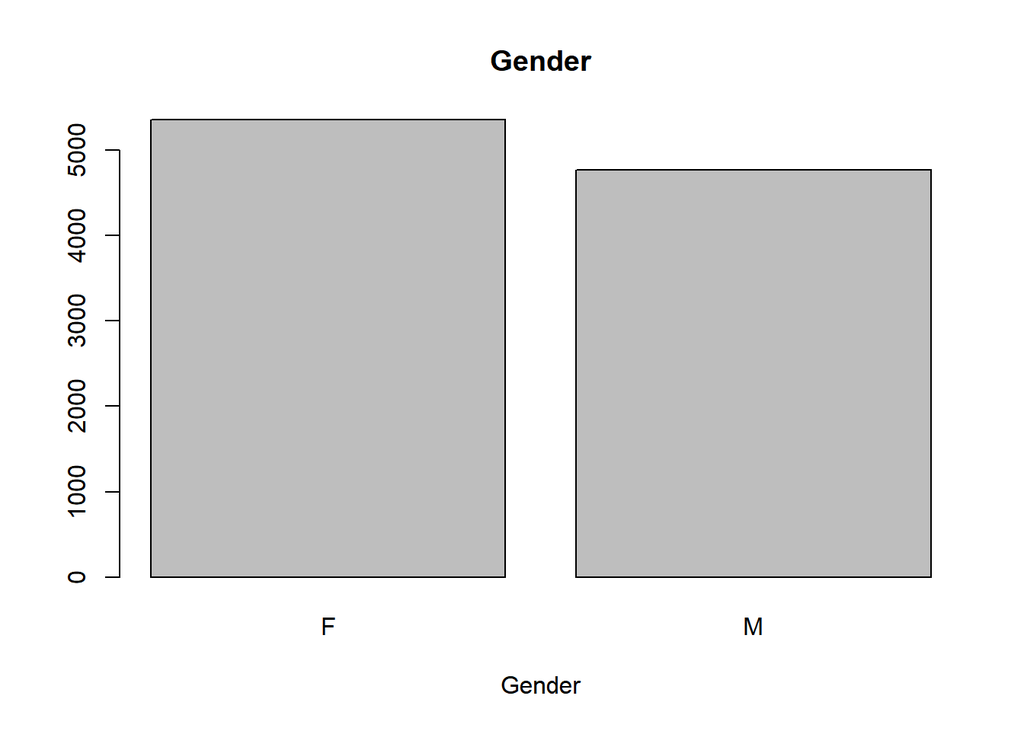

```r
b2 <- barplot(table(df$Gender), main="Gender",
   xlab="Gender")
```

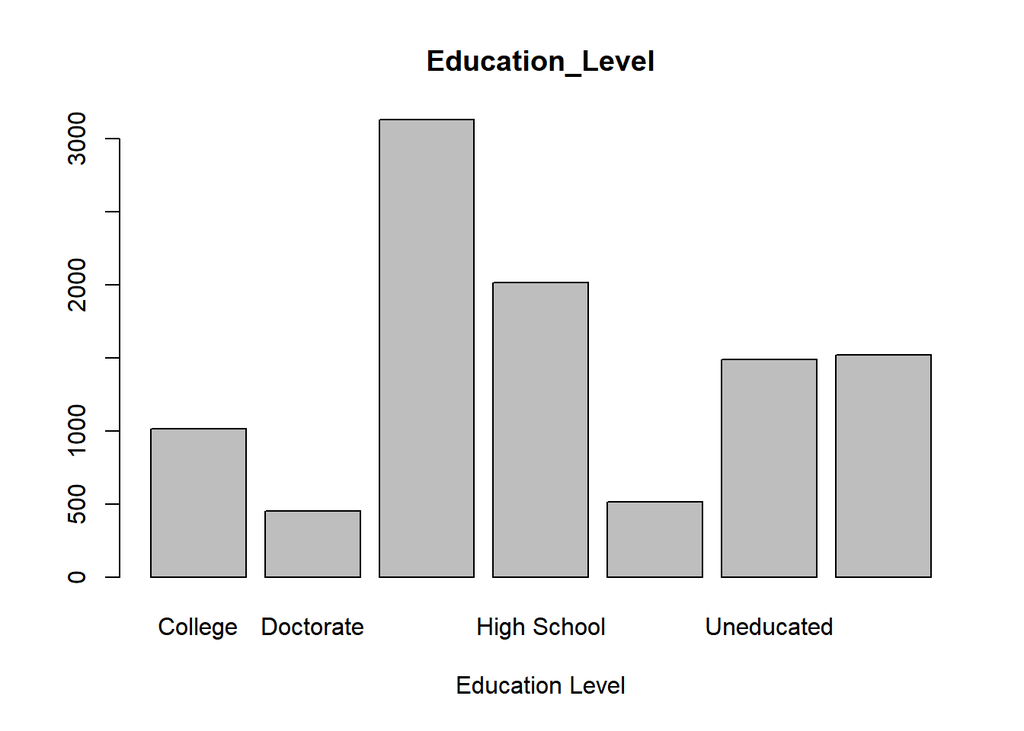

```r
b3 <- barplot(table(df$Education_Level), main="Education_Level",
   xlab="Education Level")
```

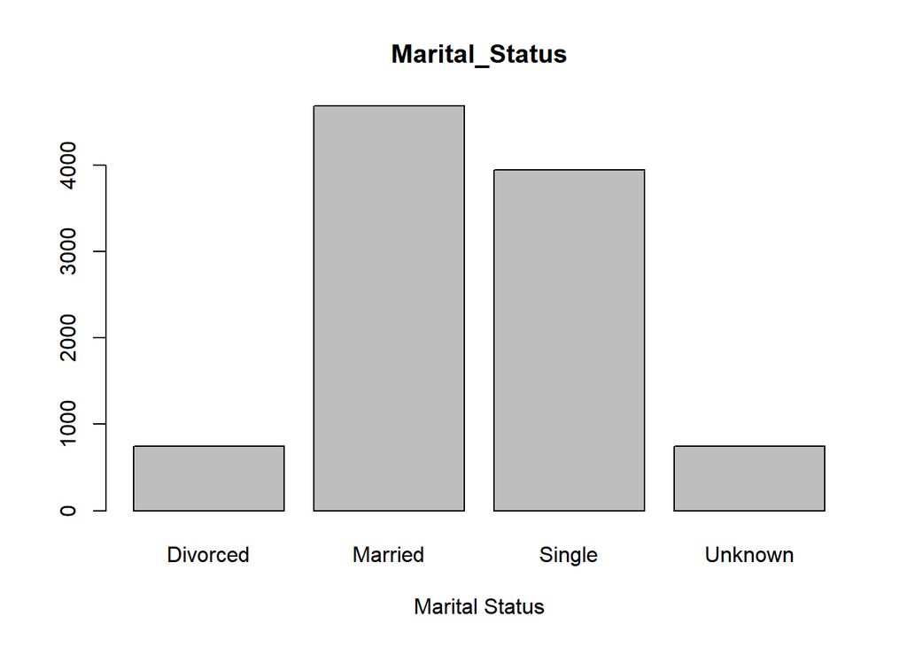

```r
b4 <- barplot(table(df$Marital_Status), main="Marital_Status",
   xlab="Marital Status")
```

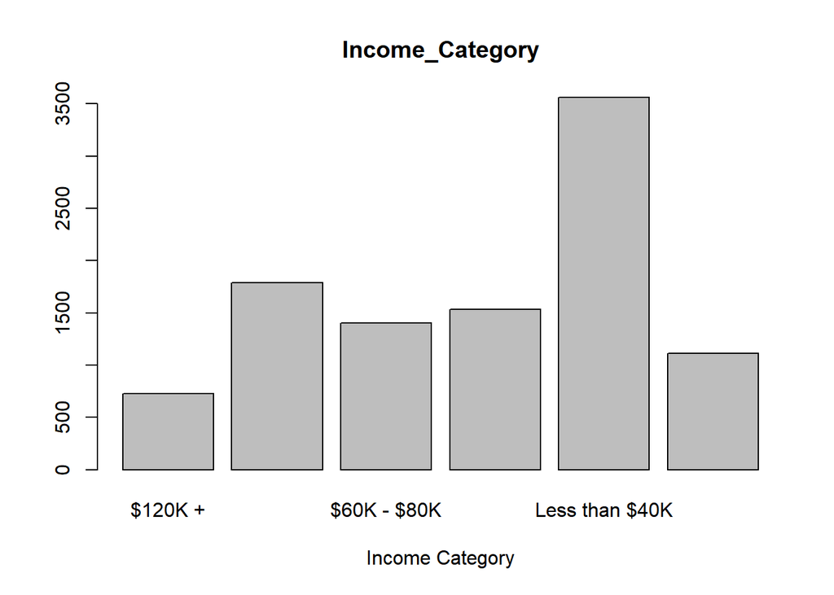

```r
b5 <- barplot(table(df$Income_Category), main="Income_Category",
   xlab="Income Category")
```

# Histograms for the numeric variables

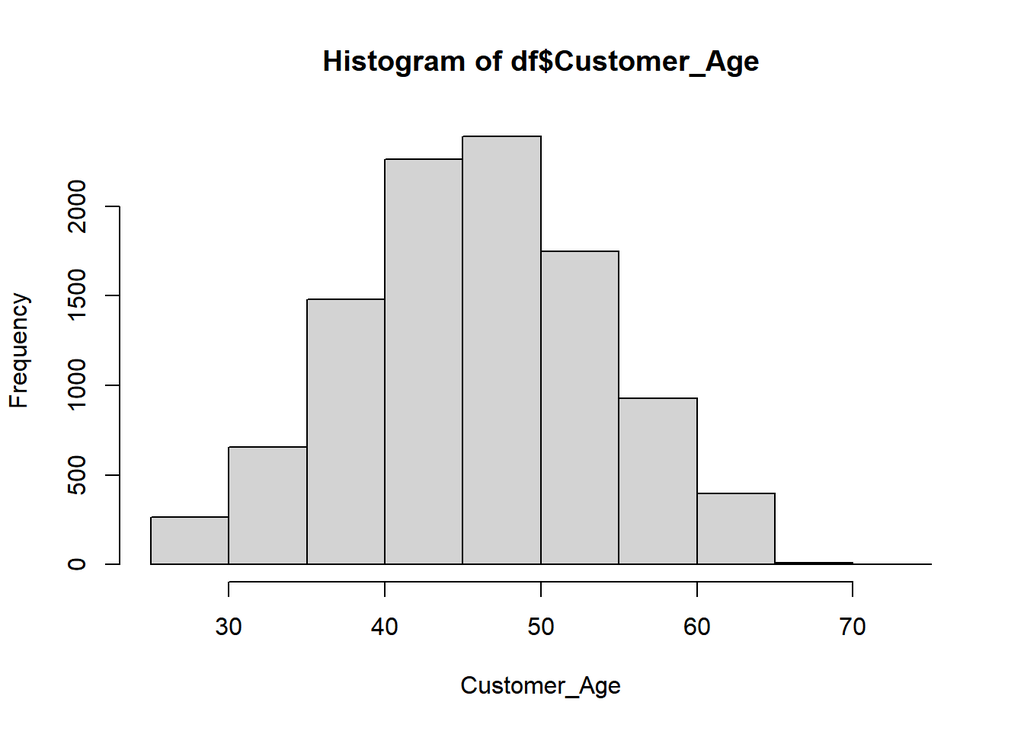

```r
hist(df$Customer_Age, xlab = "Customer_Age")
```

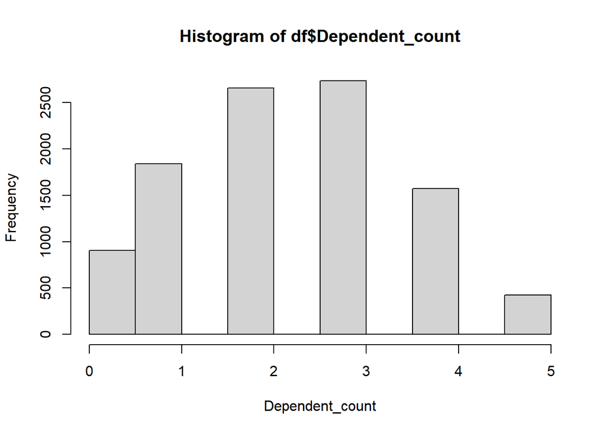

```r
hist(df$Dependent_count, xlab = "Dependent_count")
```

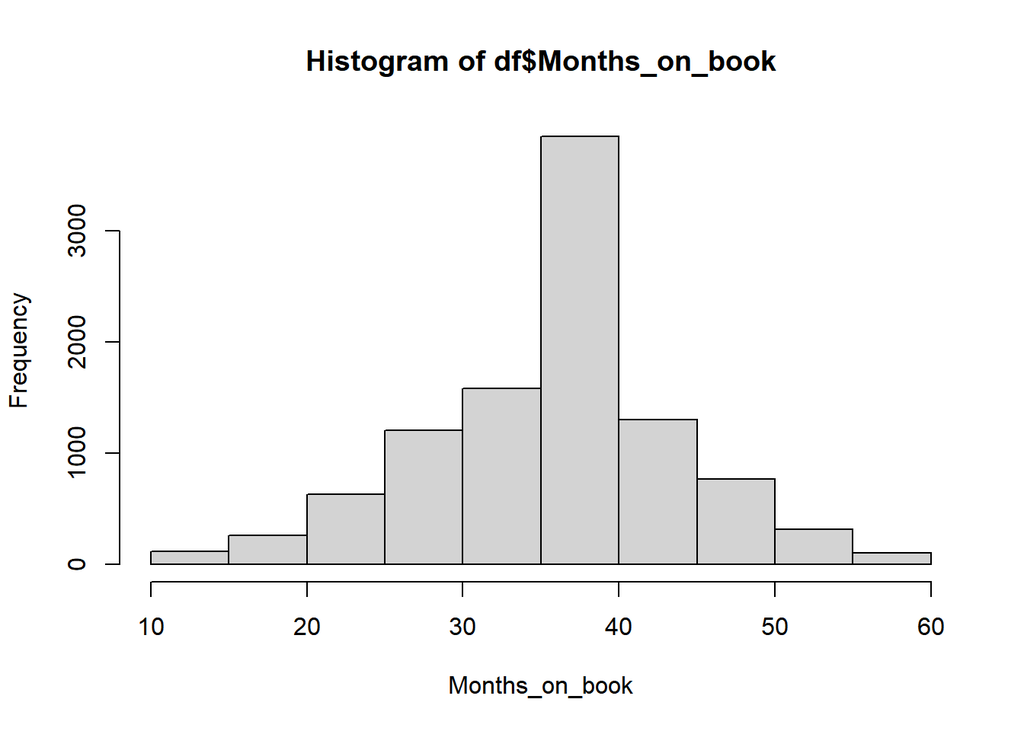

```r
hist(df$Months_on_book , xlab = "Months_on_book")
```

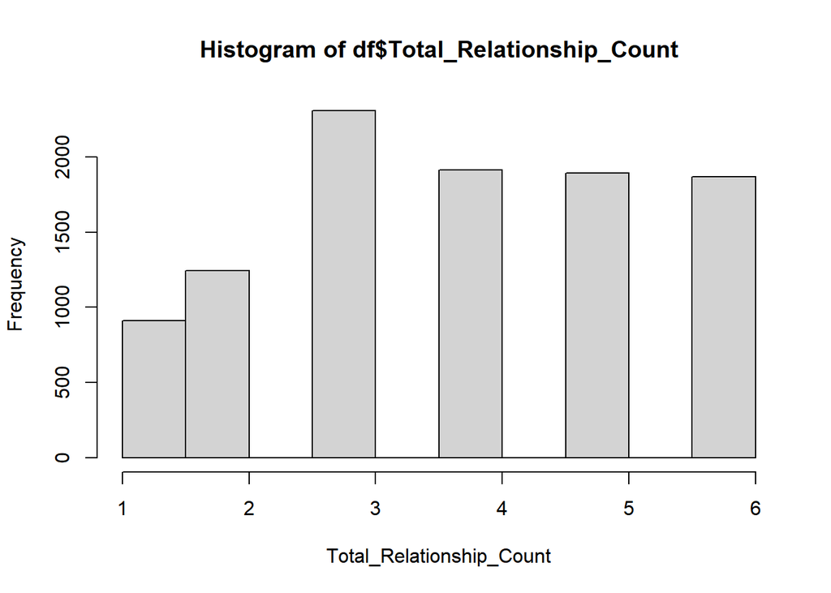

```r
hist(df$Total_Relationship_Count, xlab = "Total_Relationship_Count")
```

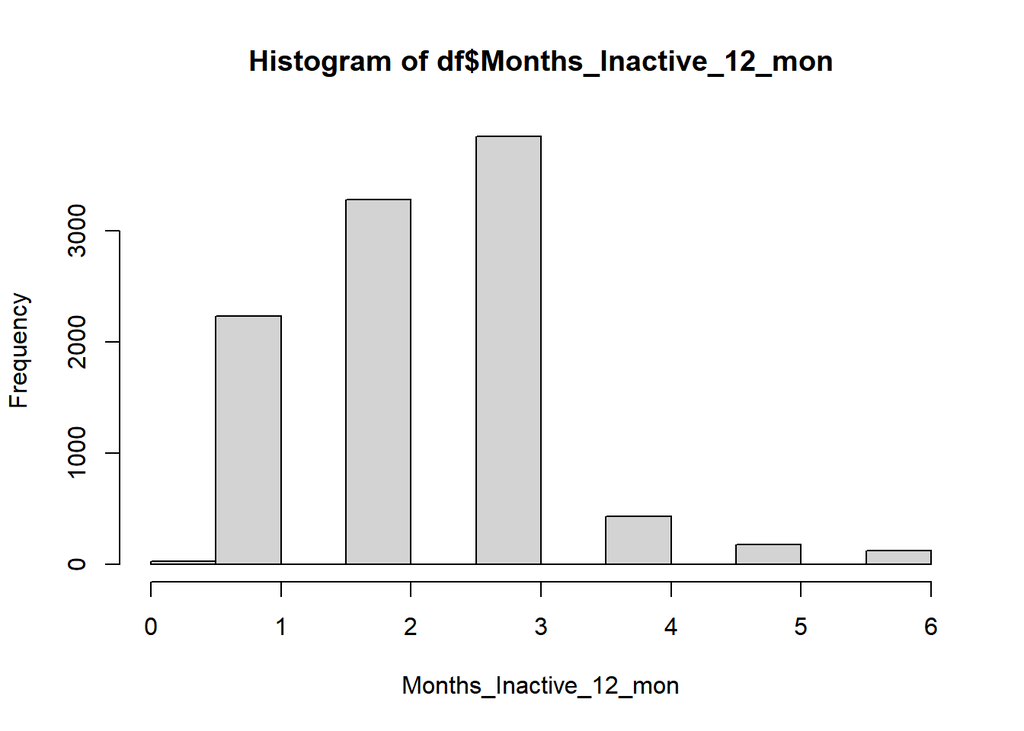

```r
hist(df$Months_Inactive_12_mon, xlab = "Months_Inactive_12_mon")
```

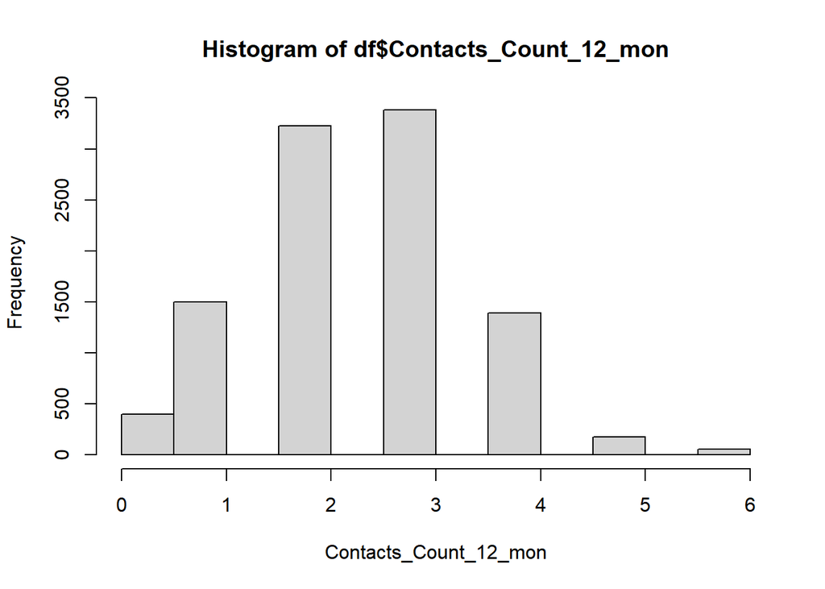

```r
hist(df$Contacts_Count_12_mon, xlab = "Contacts_Count_12_mon")
```

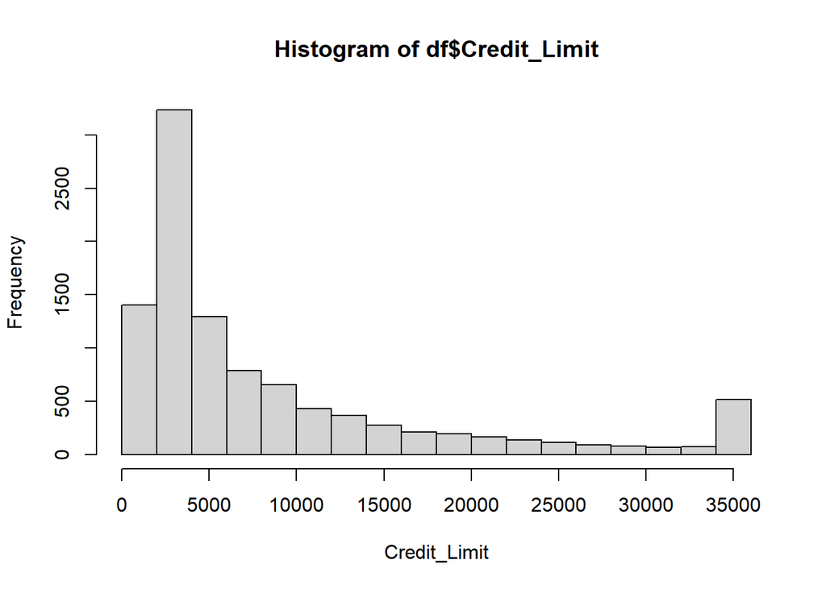

```r
hist(df$Credit_Limit , xlab = "Credit_Limit")
```

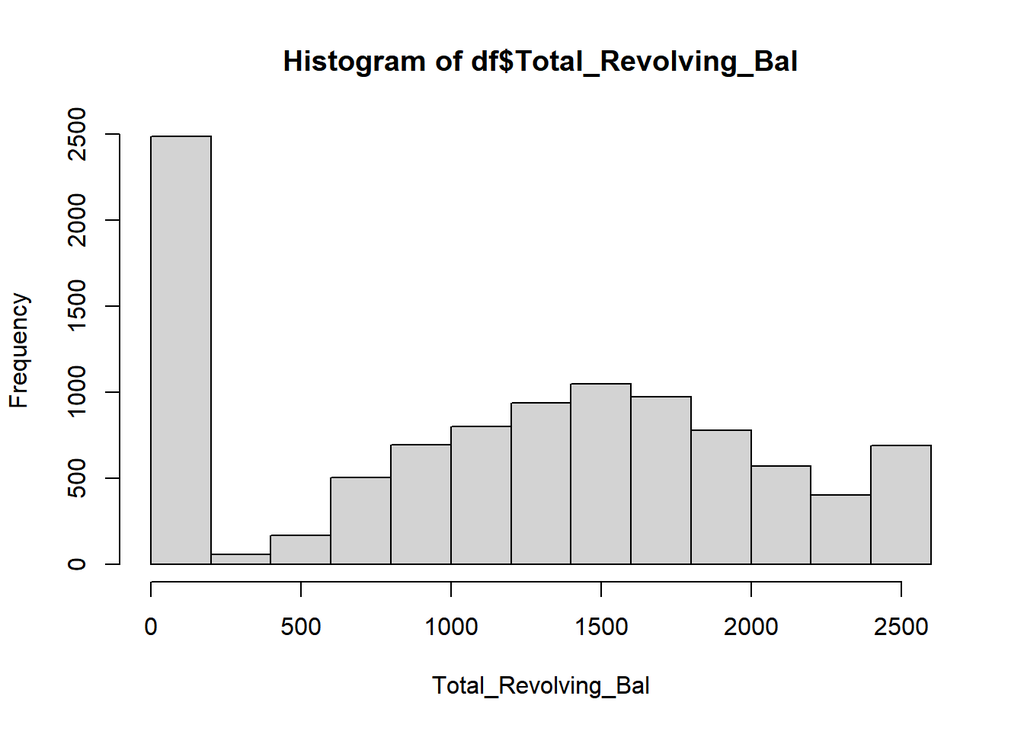

```r
hist(df$Total_Revolving_Bal, xlab = "Total_Revolving_Bal")
```

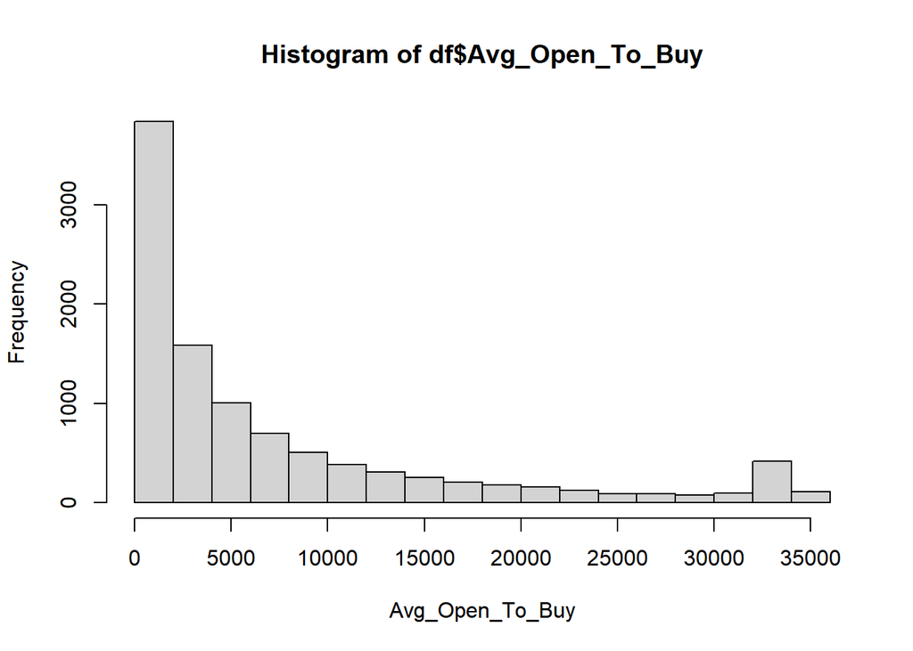

```r
hist(df$Avg_Open_To_Buy , xlab = "Avg_Open_To_Buy")
```

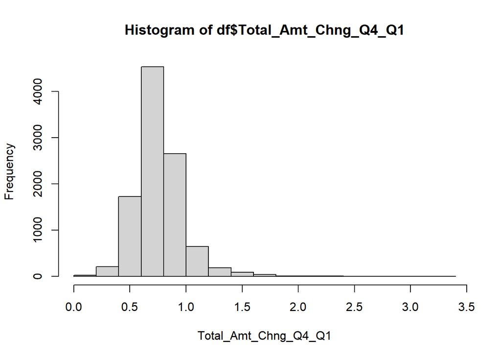

```r
hist(df$Total_Amt_Chng_Q4_Q1, xlab = "Total_Amt_Chng_Q4_Q1")
```

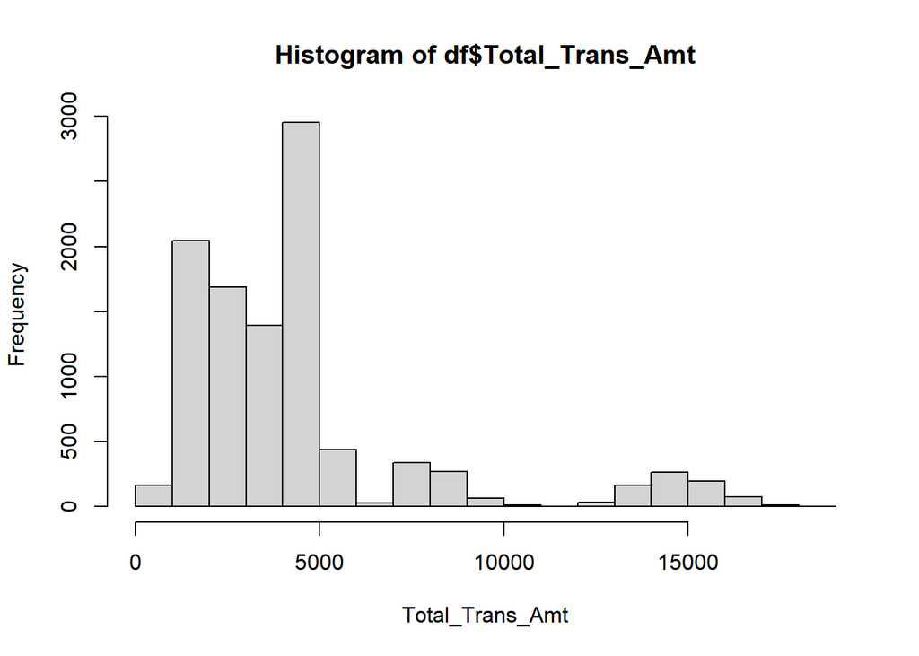

```r
hist(df$Total_Trans_Amt, xlab = "Total_Trans_Amt")
```

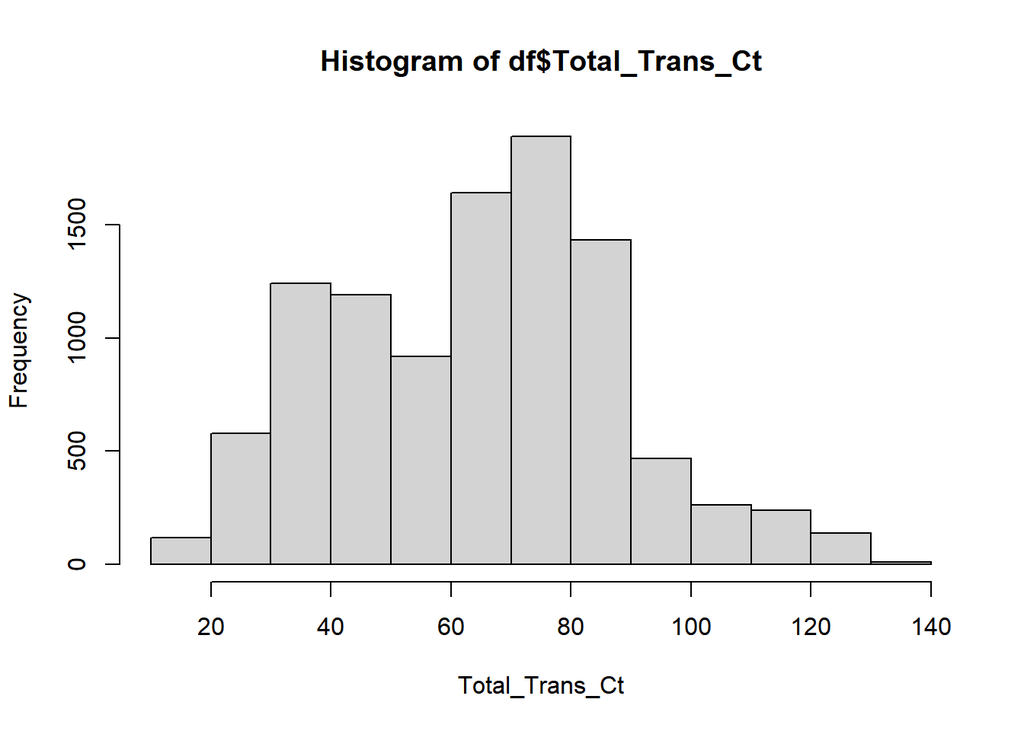

```r
hist(df$Total_Trans_Ct, xlab = "Total_Trans_Ct")
```

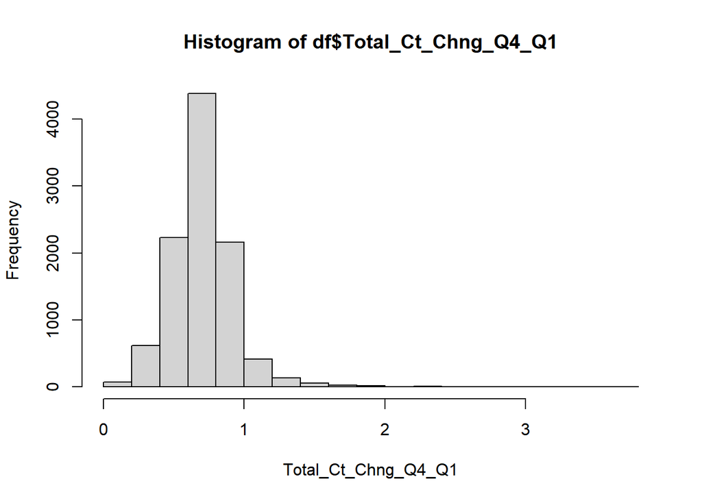

```r
hist(df$Total_Ct_Chng_Q4_Q1 , xlab = "Total_Ct_Chng_Q4_Q1")
```

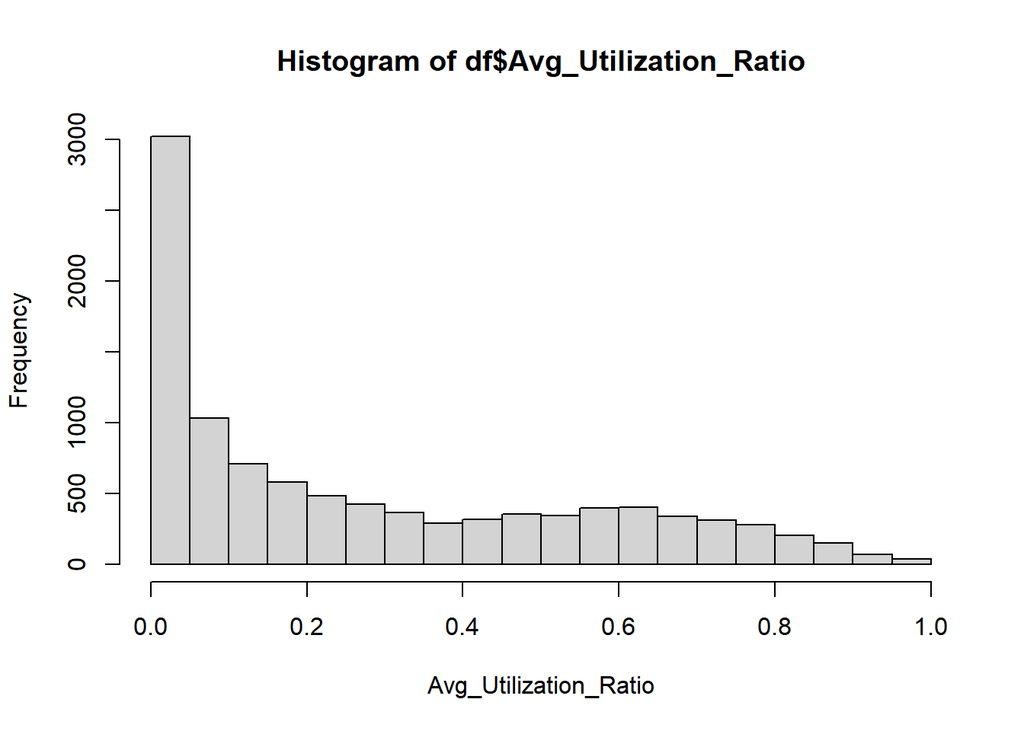

```r
hist(df$Avg_Utilization_Ratio, xlab = "Avg_Utilization_Ratio")
```

#visualization of the two variables to when compared with the other dependent variable attrition. # converting the charecteristic variable to factors.

```r
df$Attrition_Flag <- as.factor(df$Attrition_Flag)
df$Gender <- as.factor(df$Gender)
df$Education_Level <- as.factor(df$Education_Level)
df$Marital_Status <- as.factor(df$Marital_Status)
df$Income_Category <- as.factor(df$Income_Category)
df$Card_Category <- as.factor(df$Card_Category)
```

#comparing the dependent variable Attrition to other variables. # Age vs Attriritoin

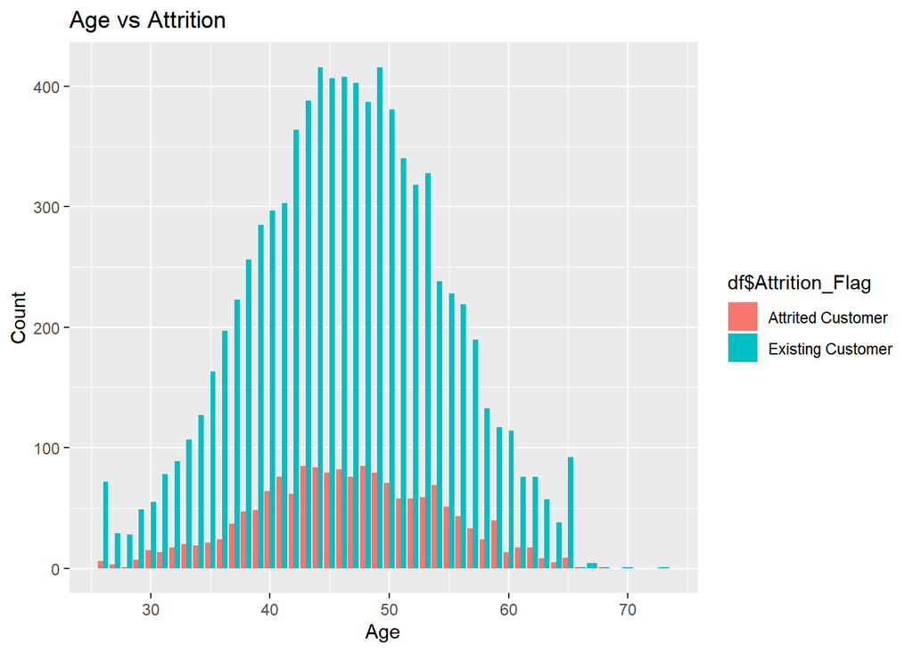

```r
pl1 <-ggplot(df, aes(x = df$Customer_Age, fill = df$Attrition_Flag)) + geom_bar(position = position_dodge())+labs(x = "Age", y = "Count", title = "Age vs Attrition")
pl1
```

#Gender vs Attrition

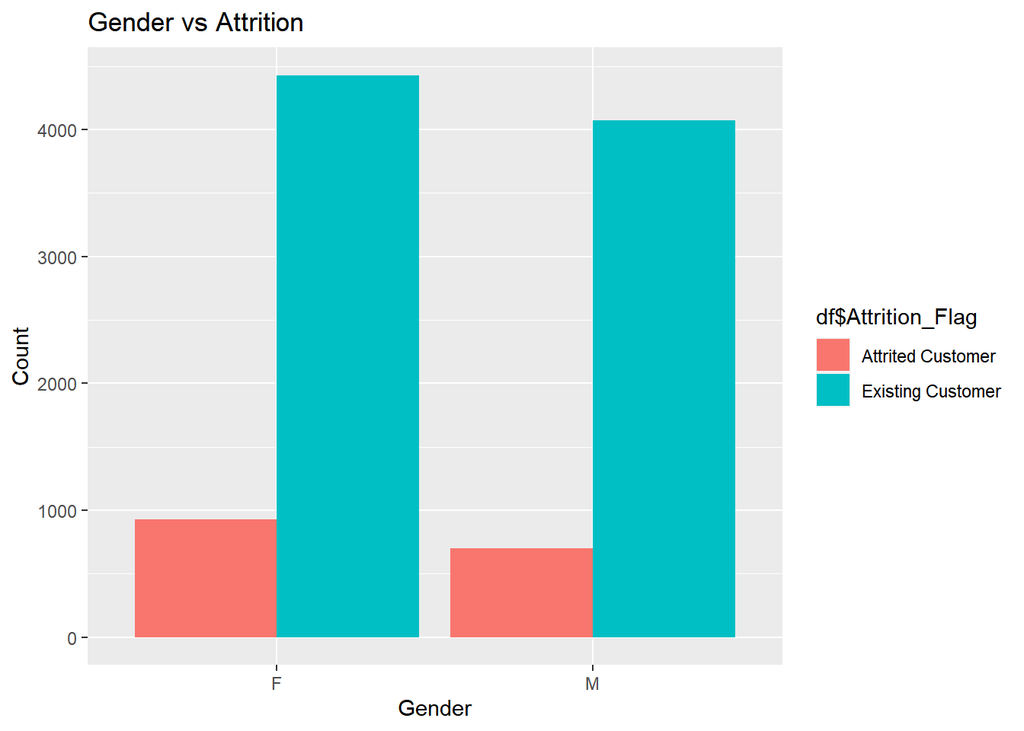

```r
pl2 <-ggplot(df, aes(x = df$Gender, fill = df$Attrition_Flag)) + geom_bar(position = position_dodge())+labs(x = "Gender", y = "Count", title = "Gender vs Attrition")
pl2
```

#Dependent count vs Attrition

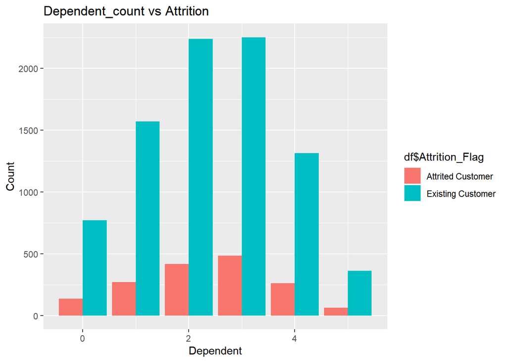

```r
pl3 <-ggplot(df, aes(x = df$Dependent_count, fill = df$Attrition_Flag)) + geom_bar(position = position_dodge())+labs(x = "Dependent", y = "Count", title = "Dependent_count vs Attrition")
pl3
```

#Education vs Attrition

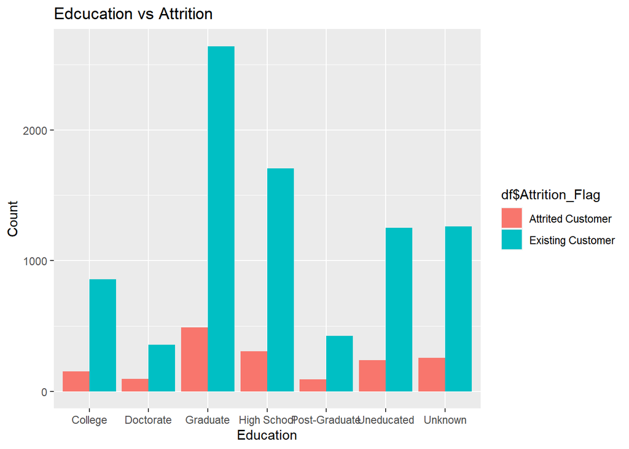

```r
pl4 <-ggplot(df, aes(x = df$Education_Level, fill = df$Attrition_Flag)) + geom_bar(position = position_dodge())+labs(x = "Education", y = "Count", title = "Edcucation vs Attrition")
pl4
```

#Marriage status vs Attrition

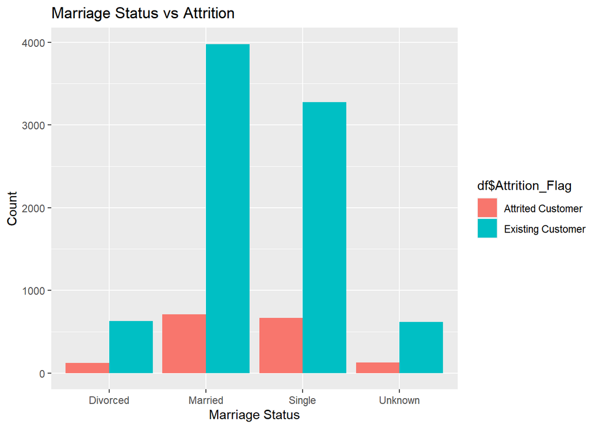

```r
pl5 <-ggplot(df, aes(x = df$Marital_Status, fill = df$Attrition_Flag)) + geom_bar(position = position_dodge())+labs(x = "Marriage Status", y = "Count", title = "Marriage Status vs Attrition")
pl5
```

#Income category vs Attrition

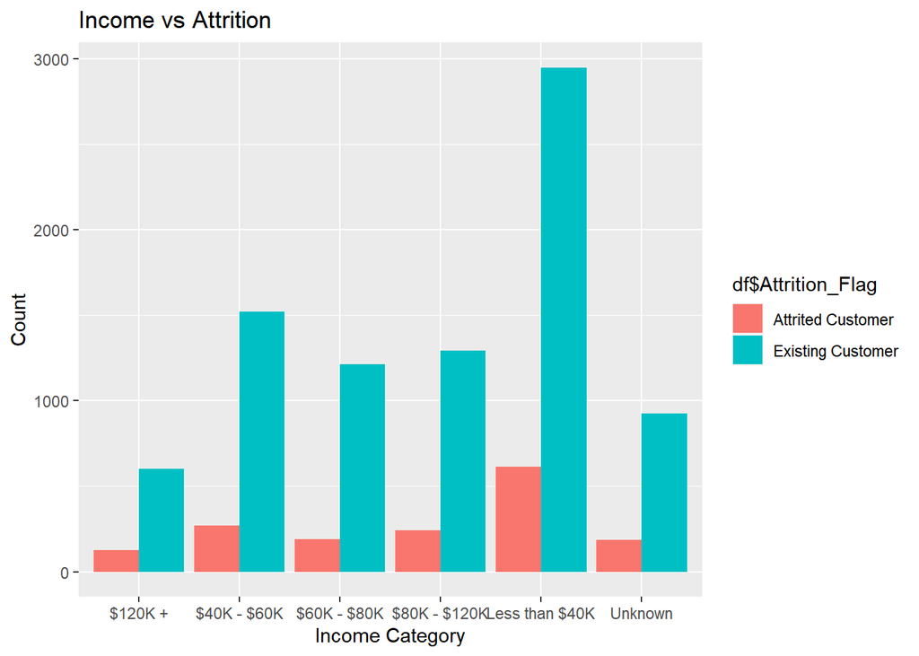

```r
pl6 <-ggplot(data = df,aes(x = df$Income_Category, fill = df$Attrition_Flag)) +
  geom_bar(position = position_dodge())+labs(x = "Income Category", y = "Count",title = "Income vs Attrition")
pl6
```

#Card Vs Attrition

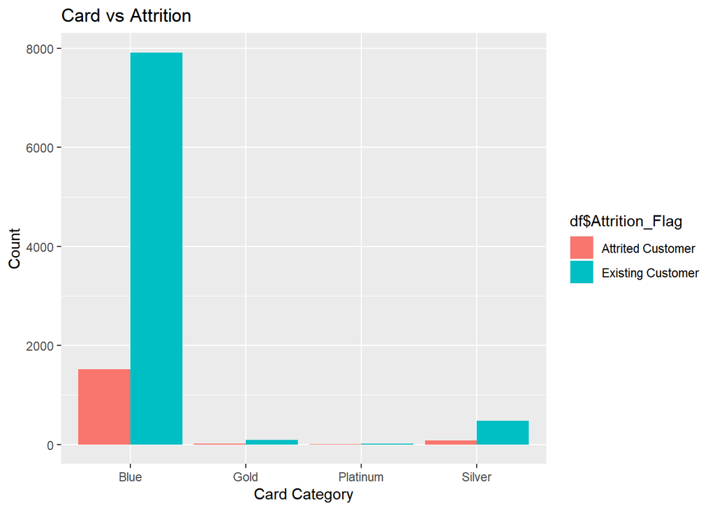

```r
pl7 <-ggplot(data = df,aes(x = df$Card_Category, fill = df$Attrition_Flag)) +
  geom_bar(position = position_dodge())+labs(x = "Card Category", y = "Count",title = "Card vs Attrition")
pl7
```

#Months on Book vs Attrition

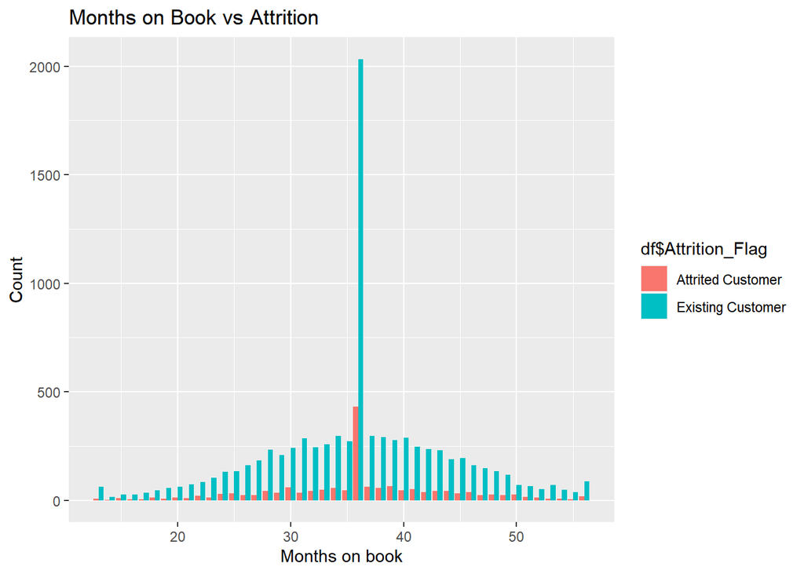

```r
pl8 <-ggplot(data = df,aes(x = df$Months_on_book, fill = df$Attrition_Flag)) +
  geom_bar(position = position_dodge())+labs(x = "Months on book", y = "Count",title = "Months on Book vs Attrition")
pl8
```

#Total Relationship count Vs Attrition

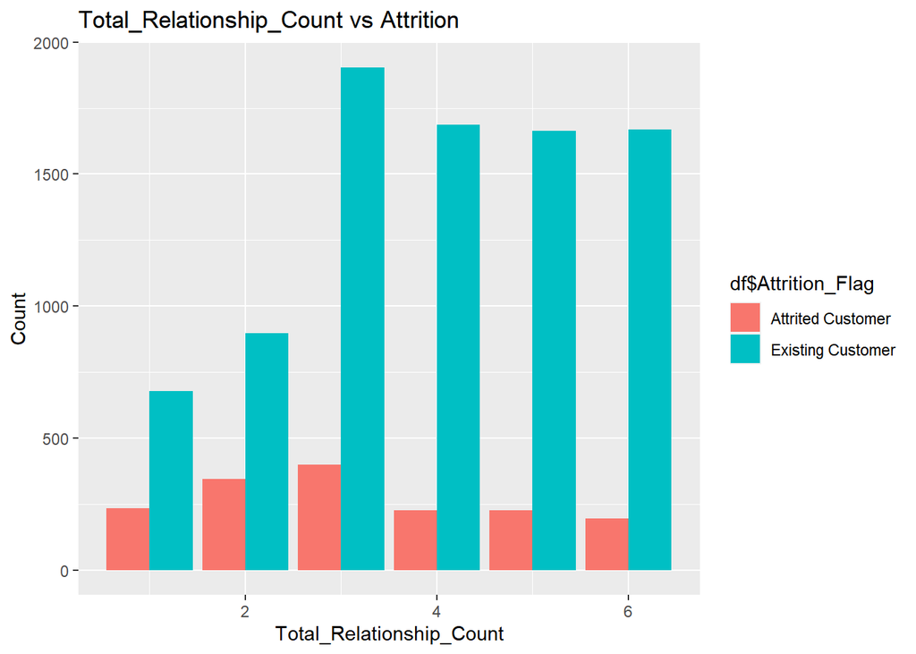

```r
pl9 <-ggplot(data = df,aes(x = df$Total_Relationship_Count, fill = df$Attrition_Flag)) +
  geom_bar(position = position_dodge())+labs(x = "Total_Relationship_Count", y = "Count",title = "Total_Relationship_Count vs Attrition")
pl9
```

#Months inactive in 12 Vs Attrition

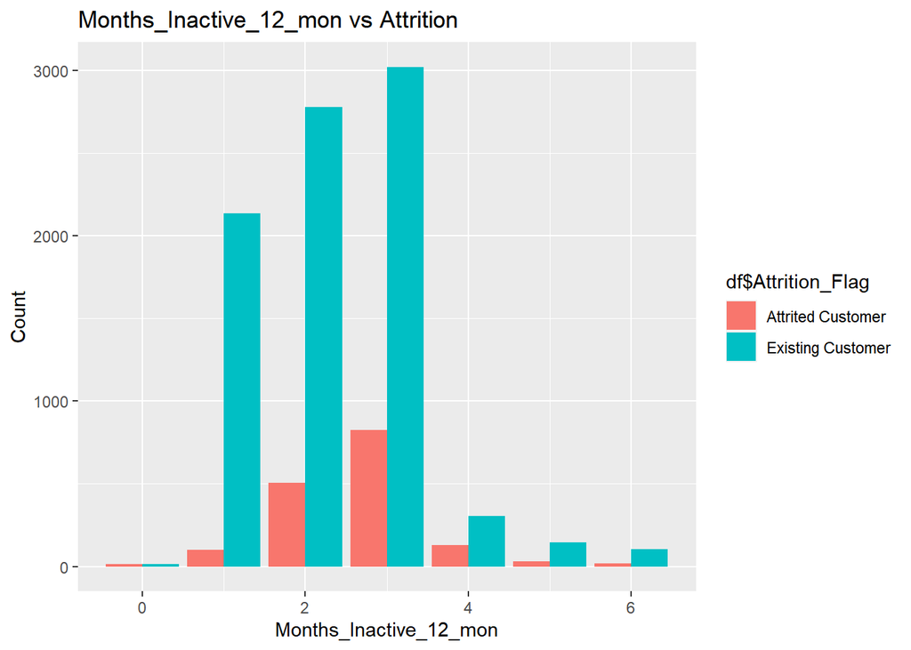

```r
pl10 <-ggplot(data = df,aes(x = df$Months_Inactive_12_mon, fill = df$Attrition_Flag)) +
  geom_bar(position = position_dodge())+labs(x = "Months_Inactive_12_mon", y = "Count",title = "Months_Inactive_12_mon vs Attrition")
pl10
```

#Contact Count vs Attirition

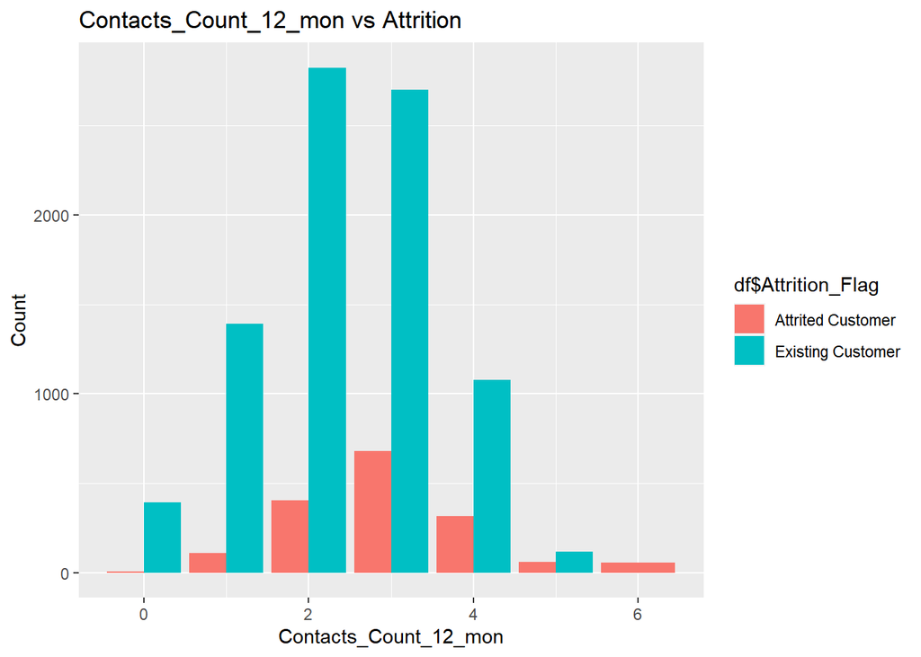

```r
pl11 <-ggplot(data = df,aes(x = df$Contacts_Count_12_mon, fill = df$Attrition_Flag)) +
  geom_bar(position = position_dodge())+labs(x = "Contacts_Count_12_mon", y = "Count",title = "Contacts_Count_12_mon vs Attrition")
pl11
```

#Credit limit Vs Attrition

[figure not shown]

```r
pl12 <-ggplot(data = df,aes(x = df$Credit_Limit, fill = df$Attrition_Flag)) +
  geom_bar(position = position_dodge())+labs(x = "Credit_Limit", y = "Count",title = "Credit_Limit vs Attrition")
pl12
```

#Total Revolving Balance Vs Attrition

[figure not shown]

```r
pl13 <-ggplot(data = df,aes(x = df$Total_Revolving_Bal, fill = df$Attrition_Flag)) +
  geom_bar(position = position_dodge())+labs(x = "Total_Revolving_Bal", y = "Count",title = "Total_Revolving_Bal vs Attrition")
pl13
```

#Avg opn to buy Vs Attrition